# Introduction to Chaos Communications

Warren Li

May 2, 2017

[figure not shown]

### History of Chaos

```python
from IPython.display import YouTubeVideo
YouTubeVideo('zhOBibeW5J0')
```

[video not shown]

### Simple nonlinear equations don't necessarily have simple behaviors!

Lorenz Equations $$ \dot{x} = \sigma(y-x) $$ $$ \dot{y} = rx - y - xz $$ $$ \dot{z} = xy - bz $$

[figure not shown]

### Definition of an Attractor

A closed set $A$ with the following properties:

1. $A$ is an invariant set: any trajectory $x(t)$ that starts in $A$ stays in $A$ for all time
2. $A$ attracts an open set of initial conditions: there is an open set $U$ containing $A$ such that if $\mathbf{x}(0) \in U$, then the distance from $\mathbf{x}(t)$ to $A$ tends to zero as $t \to \infty$. The largest such U is called the basin of attraction.
3. A is minimal: there is no proper subset of A that satisfies conditions (1) and (2).

### Divergence of nearby trajectories on the Lorenz attractor

(Strogatz, Section 9.3)

$t=3$

[figure not shown]

Numerical integration and computer graphics by Thanos Siapas, using Equation (9.2.1) with parameters $\sigma=10, b =8/3, r =28$.

$t=6$

[figure not shown]

$t=9$

[figure not shown]

$t=15$

[figure not shown]

### Definition of Chaos

There's no universal definition of chaos, but here's some basic "ingredients":

1. "Aperiodic long-term behavior" means that there are trajectories which do not settle down to fixed points, periodic orbits, or quasiperiodic orbits as $t \to \infty$.
2. "Deterministic" means that the system has no random or noisy inputs or parameters. The irregular behavior arises from the system's nonlinearity, rather than from noisy driving forces.
3. "Sensitive Dependence on inital conditions" means that nearby trajectories separate exponentially fast.

### The Double Scroll Attractor

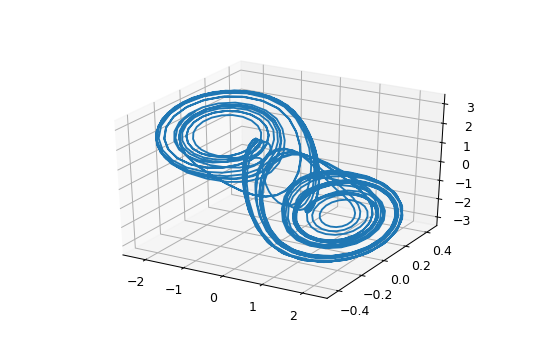

```
[<mpl_toolkits.mplot3d.art3d.Line3D at 0x1a68ff523c8>]
```

```python
%matplotlib notebook
fig = plt.figure()
ax = fig.add_subplot(111, projection='3d')
cutoff = 9000 #remove transient points

vals = runge_kutta(.1, .1, .6, 10000, 8.8, 15.0)
ax.plot(vals['x'][cutoff:], vals['y'][cutoff:], vals['z'][cutoff:])
```

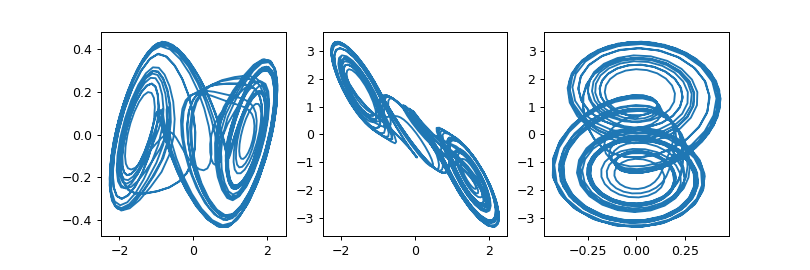

```python
fig2 = plt.figure(figsize=(9,3))
axis = fig2.add_subplot(1, 3, 1)
axis.plot(vals['x'][cutoff:], vals['y'][cutoff:])
axis = fig2.add_subplot(1, 3, 2)
plt.plot(vals['x'][cutoff:], vals['z'][cutoff:])
axis = fig2.add_subplot(1, 3, 3)
plt.plot(vals['y'][cutoff:], vals['z'][cutoff:])
```

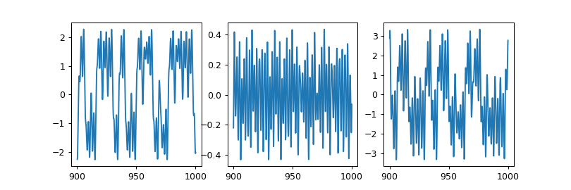

```python
fig3 = plt.figure(figsize=(9,3))
axis = fig3.add_subplot(1, 3, 1)
axis.plot(vals['t'][cutoff:], vals['x'][cutoff:])
axis = fig3.add_subplot(1, 3, 2)
plt.plot(vals['t'][cutoff:], vals['y'][cutoff:])
axis = fig3.add_subplot(1, 3, 3)
plt.plot(vals['t'][cutoff:], vals['z'][cutoff:])
```

### Circuit Representation

|  | $$\dot{x} = \alpha[y-x-f(x)]$$ $$RC_2\dot{y} = x-y+Rz$$ $$\dot{z} = -\beta y$$ |
| --- | --- |

[figure not shown]

### Proof of Synchronization

[figure not shown]

```python
from IPython.display import HTML
HTML("""
<video width="500" height="380" controls>
  <source src="sync.mp4" type="video/mp4">
</video>
""")
```

[video not shown]

### Transmission Scheme

1. Parameter Modulation
2. Digipot & Master/Slave Configuration

```python
HTML("""
<video width="500" height="380" controls>
  <source src="error.mp4" type="video/mp4">
</video>
""")
```

[video not shown]

```python
HTML("""
<video width="500" height="380" controls>
  <source src="transmit.mp4" type="video/mp4">
</video>
""")
```

[video not shown]

Decoding the Waveform